# Восстановление золота из руды

Подготовьте прототип модели машинного обучения для «Цифры». Компания разрабатывает решения для эффективной работы промышленных предприятий.

Модель должна предсказать коэффициент восстановления золота из золотосодержащей руды. Используйте данные с параметрами добычи и очистки.

Модель поможет оптимизировать производство, чтобы не запускать предприятие с убыточными характеристиками.

Вам нужно:

1. Подготовить данные;
2. Провести исследовательский анализ данных;
3. Построить и обучить модель.

Чтобы выполнить проект, обращайтесь к библиотекам *pandas*, *matplotlib* и *sklearn.* Вам поможет их документация.

## Подготовка данных

Подключаемые все необходимые для выполнения исследования библиотеки:

```python
import pandas as pd # работа с табличными данными

import numpy as np # векторные операции

from sklearn.model_selection import train_test_split # выделение обучающей и тестовой выборок
from sklearn.model_selection import GridSearchCV # подбор гиперпараметров для лучшей модели
from sklearn.model_selection import cross_val_score # кросс-валидация

from sklearn.preprocessing import StandardScaler # масштабирование признаков
from sklearn.preprocessing import OrdinalEncoder # порядковое кодирование

from sklearn.tree import DecisionTreeRegressor # решающее дерево
from sklearn.ensemble import RandomForestRegressor # случайный лес
from sklearn.linear_model import LinearRegression # модель линейной регрессии

from sklearn.metrics import mean_absolute_error # метрика MAE
from sklearn.metrics import make_scorer # использование своей функции потерь

from sklearn.dummy import DummyRegressor # случайная модель

from sklearn.utils import shuffle

import seaborn as sns # работа с графикой
```

### Обучающий набор данных

*Раньше для разведочного анализа данных использовал библиотеку pandas-profiling, но в этом проекте при запуске ProfileReport "умирает" ядро (возможно из-за большого количества признаков)*

Загружаем файл с обучающим набором данных и выводим общую информацию о нём:

```python
train_data = pd.read_csv('/datasets/gold_recovery_train_new.csv') # загружаем данные
train_data.info() # выводим общую информацию
```

```
<class 'pandas.core.frame.DataFrame'>
RangeIndex: 14149 entries, 0 to 14148
Data columns (total 87 columns):
 #   Column                                              Non-Null Count  Dtype
---  ------                                              --------------  -----
 0   date                                                14149 non-null  object
 1   final.output.concentrate_ag                         14148 non-null  float64
 2   final.output.concentrate_pb                         14148 non-null  float64
 3   final.output.concentrate_sol                        13938 non-null  float64
 4   final.output.concentrate_au                         14149 non-null  float64
 5   final.output.recovery                               14149 non-null  float64
 6   final.output.tail_ag                                14149 non-null  float64
 7   final.output.tail_pb                                14049 non-null  float64
 8   final.output.tail_sol                               14144 non-null  float64
 9   final.output.tail_au                                14149 non-null  float64
```

[output cut: 79 more lines]

Изучаем данные:

```python
train_data.head(10)
```

|  | date | final.output.concentrate_ag | final.output.concentrate_pb | final.output.concentrate_sol | final.output.concentrate_au | final.output.recovery | final.output.tail_ag | final.output.tail_pb | final.output.tail_sol | final.output.tail_au | ... | secondary_cleaner.state.floatbank4_a_air | secondary_cleaner.state.floatbank4_a_level | secondary_cleaner.state.floatbank4_b_air | secondary_cleaner.state.floatbank4_b_level | secondary_cleaner.state.floatbank5_a_air | secondary_cleaner.state.floatbank5_a_level | secondary_cleaner.state.floatbank5_b_air | secondary_cleaner.state.floatbank5_b_level | secondary_cleaner.state.floatbank6_a_air | secondary_cleaner.state.floatbank6_a_level |
| --- | --- | --- | --- | --- | --- | --- | --- | --- | --- | --- | --- | --- | --- | --- | --- | --- | --- | --- | --- | --- | --- |
| 0 | 2016-01-15 00:00:00 | 6.055403 | 9.889648 | 5.507324 | 42.192020 | 70.541216 | 10.411962 | 0.895447 | 16.904297 | 2.143149 | ... | 14.016835 | -502.488007 | 12.099931 | -504.715942 | 9.925633 | -498.310211 | 8.079666 | -500.470978 | 14.151341 | -605.841980 |
| 1 | 2016-01-15 01:00:00 | 6.029369 | 9.968944 | 5.257781 | 42.701629 | 69.266198 | 10.462676 | 0.927452 | 16.634514 | 2.224930 | ... | 13.992281 | -505.503262 | 11.950531 | -501.331529 | 10.039245 | -500.169983 | 7.984757 | -500.582168 | 13.998353 | -599.787184 |
| 2 | 2016-01-15 02:00:00 | 6.055926 | 10.213995 | 5.383759 | 42.657501 | 68.116445 | 10.507046 | 0.953716 | 16.208849 | 2.257889 | ... | 14.015015 | -502.520901 | 11.912783 | -501.133383 | 10.070913 | -500.129135 | 8.013877 | -500.517572 | 14.028663 | -601.427363 |
| 3 | 2016-01-15 03:00:00 | 6.047977 | 9.977019 | 4.858634 | 42.689819 | 68.347543 | 10.422762 | 0.883763 | 16.532835 | 2.146849 | ... | 14.036510 | -500.857308 | 11.999550 | -501.193686 | 9.970366 | -499.201640 | 7.977324 | -500.255908 | 14.005551 | -599.996129 |
| 4 | 2016-01-15 04:00:00 | 6.148599 | 10.142511 | 4.939416 | 42.774141 | 66.927016 | 10.360302 | 0.792826 | 16.525686 | 2.055292 | ... | 14.027298 | -499.838632 | 11.953070 | -501.053894 | 9.925709 | -501.686727 | 7.894242 | -500.356035 | 13.996647 | -601.496691 |
| 5 | 2016-01-15 05:00:00 | 6.482968 | 10.049416 | 5.480257 | 41.633678 | 69.465816 | 10.182708 | 0.664118 | 16.999638 | 1.918586 | ... | 13.938497 | -500.970168 | 11.883350 | -500.395298 | 10.054147 | -496.374715 | 7.965083 | -499.364752 | 14.017067 | -599.707915 |
| 6 | 2016-01-15 06:00:00 | 6.533849 | 10.058141 | 4.569100 | 41.995316 | 69.300835 | 10.304598 | 0.807342 | 16.723575 | 2.058913 | ... | 14.046819 | -500.971133 | 12.091543 | -500.501426 | 10.003247 | -497.083180 | 8.010890 | -500.002423 | 14.029649 | -600.905470 |
| 7 | 2016-01-15 07:00:00 | 6.130823 | 9.935481 | 4.389813 | 42.452727 | 70.230976 | 10.443288 | 0.949346 | 16.689959 | 2.143437 | ... | 13.974691 | -501.819696 | 12.101324 | -500.583446 | 9.873169 | -499.171928 | 7.993381 | -499.794518 | 13.984498 | -600.411070 |
| 8 | 2016-01-15 08:00:00 | 5.834140 | 10.071156 | 4.876389 | 43.404078 | 69.688595 | 10.420140 | 1.065453 | 17.201948 | 2.209881 | ... | 13.964030 | -504.252450 | 12.060738 | -501.174549 | 10.033838 | -501.178133 | 7.881604 | -499.729434 | 13.967135 | -599.061188 |
| 9 | 2016-01-15 09:00:00 | 5.687063 | 9.980404 | 5.282514 | 43.235220 | 70.279619 | 10.487013 | 1.159805 | 17.483979 | 2.209593 | ... | 13.989632 | -503.195299 | 12.052233 | -500.928547 | 9.962574 | -502.986357 | 7.979219 | -500.146835 | 13.981614 | -598.070855 |

10 rows × 87 columns

Определяем, в каких признаках есть пропуски:

```python
columns_with_gaps = train_data.isna().sum() # считам количество пропусков

columns_with_gaps = pd.DataFrame({'Признак': columns_with_gaps.index,
                                'Пропусков': columns_with_gaps.values,
                                 'Доля, %': columns_with_gaps.values / len(train_data) * 100
                                 }) # Результат оформляем в виде таблицы
columns_with_gaps.query('Пропусков != 0').sort_values('Пропусков', ascending=False).head(10) # выводим результат
```

|  | Признак | Пропусков | Доля, % |
| --- | --- | --- | --- |
| 67 | secondary_cleaner.output.tail_sol | 1605 | 11.343558 |
| 61 | rougher.state.floatbank10_e_air | 436 | 3.081490 |
| 43 | rougher.input.floatbank11_xanthate | 428 | 3.024949 |
| 16 | primary_cleaner.output.concentrate_sol | 286 | 2.021344 |
| 69 | secondary_cleaner.state.floatbank2_a_air | 217 | 1.533677 |
| 3 | final.output.concentrate_sol | 211 | 1.491271 |
| 37 | rougher.input.feed_size | 144 | 1.017740 |
| 7 | final.output.tail_pb | 100 | 0.706764 |
| 35 | rougher.input.feed_pb | 100 | 0.706764 |
| 13 | primary_cleaner.input.xanthate | 100 | 0.706764 |

Проверяем на наличие явных дубликатов:

```python
train_data.duplicated().sum()
```

```
0
```

#### Корректность расчёта эффективности обогащения

Проверяем, что эффективность обогащения рассчитана правильно. Вычисляем её на обучающей выборке для признака rougher.output.recovery (эффективность обогащения после флотации). Находим MAE между нашими расчётами и значением признака:

```python
required_columns_for_recovery = train_data[['rougher.output.recovery',
                                            'rougher.output.concentrate_au',
                                            'rougher.input.feed_au',
                                            'rougher.output.tail_au'
                                           ]].dropna() # где-то появляется значение NA из-за которого расчёты МАЕ
                                                       # невозможны - избавляемся от него

rougher_output_recovery = required_columns_for_recovery['rougher.output.recovery'] # значения в обучающем наборе

C = required_columns_for_recovery['rougher.output.concentrate_au'] # доля золота в черновом концентрате после флотации
F = required_columns_for_recovery['rougher.input.feed_au'] # доля золота в сырье/концентрате до флотации/очистки
T = required_columns_for_recovery['rougher.output.tail_au'] # доля золота в отвальных хвостах после флотации/очистки
rougher_output_recovery_calculation = C * (F - T) / (F * (C - T)) * 100 # расчётное значение
```

```python
MAE = mean_absolute_error(rougher_output_recovery, rougher_output_recovery_calculation)
print('MAE:', MAE)
```

```
MAE: 9.73512347450521e-15
```

**Выводы**

Низкое значение MAE, близкое к нулю, говорит о том, что эффективность обогащения в исходном наборе данных рассчитана кооректно.

### Тестовый набор данных

Загружаем тестовый набор данных и выводим общую информацию о нём:

```python
test_data = pd.read_csv('/datasets/gold_recovery_test_new.csv') # загружаем
test_data.info() # выводим общую информацию
```

```
<class 'pandas.core.frame.DataFrame'>
RangeIndex: 5290 entries, 0 to 5289
Data columns (total 53 columns):
 #   Column                                      Non-Null Count  Dtype
---  ------                                      --------------  -----
 0   date                                        5290 non-null   object
 1   primary_cleaner.input.sulfate               5286 non-null   float64
 2   primary_cleaner.input.depressant            5285 non-null   float64
 3   primary_cleaner.input.feed_size             5290 non-null   float64
 4   primary_cleaner.input.xanthate              5286 non-null   float64
 5   primary_cleaner.state.floatbank8_a_air      5290 non-null   float64
 6   primary_cleaner.state.floatbank8_a_level    5290 non-null   float64
 7   primary_cleaner.state.floatbank8_b_air      5290 non-null   float64
 8   primary_cleaner.state.floatbank8_b_level    5290 non-null   float64
 9   primary_cleaner.state.floatbank8_c_air      5290 non-null   float64
```

[output cut: 45 more lines]

Изучаем данные:

```python
test_data.head(10)
```

|  | date | primary_cleaner.input.sulfate | primary_cleaner.input.depressant | primary_cleaner.input.feed_size | primary_cleaner.input.xanthate | primary_cleaner.state.floatbank8_a_air | primary_cleaner.state.floatbank8_a_level | primary_cleaner.state.floatbank8_b_air | primary_cleaner.state.floatbank8_b_level | primary_cleaner.state.floatbank8_c_air | ... | secondary_cleaner.state.floatbank4_a_air | secondary_cleaner.state.floatbank4_a_level | secondary_cleaner.state.floatbank4_b_air | secondary_cleaner.state.floatbank4_b_level | secondary_cleaner.state.floatbank5_a_air | secondary_cleaner.state.floatbank5_a_level | secondary_cleaner.state.floatbank5_b_air | secondary_cleaner.state.floatbank5_b_level | secondary_cleaner.state.floatbank6_a_air | secondary_cleaner.state.floatbank6_a_level |
| --- | --- | --- | --- | --- | --- | --- | --- | --- | --- | --- | --- | --- | --- | --- | --- | --- | --- | --- | --- | --- | --- |
| 0 | 2016-09-01 00:59:59 | 210.800909 | 14.993118 | 8.080000 | 1.005021 | 1398.981301 | -500.225577 | 1399.144926 | -499.919735 | 1400.102998 | ... | 12.023554 | -497.795834 | 8.016656 | -501.289139 | 7.946562 | -432.317850 | 4.872511 | -500.037437 | 26.705889 | -499.709414 |
| 1 | 2016-09-01 01:59:59 | 215.392455 | 14.987471 | 8.080000 | 0.990469 | 1398.777912 | -500.057435 | 1398.055362 | -499.778182 | 1396.151033 | ... | 12.058140 | -498.695773 | 8.130979 | -499.634209 | 7.958270 | -525.839648 | 4.878850 | -500.162375 | 25.019940 | -499.819438 |
| 2 | 2016-09-01 02:59:59 | 215.259946 | 12.884934 | 7.786667 | 0.996043 | 1398.493666 | -500.868360 | 1398.860436 | -499.764529 | 1398.075709 | ... | 11.962366 | -498.767484 | 8.096893 | -500.827423 | 8.071056 | -500.801673 | 4.905125 | -499.828510 | 24.994862 | -500.622559 |
| 3 | 2016-09-01 03:59:59 | 215.336236 | 12.006805 | 7.640000 | 0.863514 | 1399.618111 | -498.863574 | 1397.440120 | -499.211024 | 1400.129303 | ... | 12.033091 | -498.350935 | 8.074946 | -499.474407 | 7.897085 | -500.868509 | 4.931400 | -499.963623 | 24.948919 | -498.709987 |
| 4 | 2016-09-01 04:59:59 | 199.099327 | 10.682530 | 7.530000 | 0.805575 | 1401.268123 | -500.808305 | 1398.128818 | -499.504543 | 1402.172226 | ... | 12.025367 | -500.786497 | 8.054678 | -500.397500 | 8.107890 | -509.526725 | 4.957674 | -500.360026 | 25.003331 | -500.856333 |
| 5 | 2016-09-01 05:59:59 | 168.485085 | 8.817007 | 7.420000 | 0.791191 | 1402.826803 | -499.299521 | 1401.511119 | -499.205357 | 1404.088107 | ... | 12.029797 | -499.814895 | 8.036586 | -500.371492 | 8.041446 | -510.037054 | 4.983949 | -499.990990 | 24.978973 | -500.475640 |
| 6 | 2016-09-01 06:59:59 | 144.133440 | 7.924610 | 7.420000 | 0.788838 | 1398.252401 | -499.748672 | 1393.255503 | -499.195380 | 1396.738566 | ... | 12.026296 | -499.473127 | 8.027984 | -500.983079 | 7.907340 | -507.964971 | 5.010224 | -500.043697 | 25.040709 | -499.501984 |
| 7 | 2016-09-01 07:59:59 | 133.513396 | 8.055252 | 6.988000 | 0.801871 | 1401.669677 | -501.777839 | 1400.754446 | -502.514024 | 1400.465244 | ... | 12.040911 | -501.293852 | 8.020490 | -499.185229 | 8.116897 | -511.927561 | 5.036498 | -500.149615 | 25.032580 | -503.970657 |
| 8 | 2016-09-01 08:59:59 | 133.735356 | 7.999618 | 6.935000 | 0.789329 | 1402.358981 | -499.981597 | 1400.985954 | -496.802968 | 1401.168584 | ... | 11.998184 | -499.481608 | 8.012610 | -500.896783 | 7.974422 | -521.199104 | 5.061599 | -499.791519 | 25.005063 | -497.613716 |
| 9 | 2016-09-01 09:59:59 | 126.961069 | 8.017856 | 7.030000 | 0.805298 | 1400.816120 | -499.014158 | 1399.975401 | -499.570552 | 1401.871924 | ... | 12.040725 | -499.987743 | 7.989503 | -499.750625 | 7.989710 | -509.946737 | 5.068811 | -499.293900 | 24.992741 | -499.272255 |

10 rows × 53 columns

Определяем, в каких признаках есть пропуски:

```python
columns_with_gaps = test_data.isna().sum() # считам количество пропусков

columns_with_gaps = pd.DataFrame({'Признак': columns_with_gaps.index,
                                'Пропусков': columns_with_gaps.values,
                                 'Доля, %': columns_with_gaps.values / len(train_data) * 100
                                 }) # Результат оформляем в виде таблицы
columns_with_gaps.query('Пропусков != 0').sort_values('Пропусков', ascending=False).head(10) # выводим результат
```

|  | Признак | Пропусков | Доля, % |
| --- | --- | --- | --- |
| 22 | rougher.input.floatbank11_xanthate | 25 | 0.176691 |
| 17 | rougher.input.feed_sol | 21 | 0.148420 |
| 39 | secondary_cleaner.state.floatbank3_a_air | 9 | 0.063609 |
| 21 | rougher.input.floatbank11_sulfate | 8 | 0.056541 |
| 2 | primary_cleaner.input.depressant | 5 | 0.035338 |
| 19 | rougher.input.floatbank10_sulfate | 5 | 0.035338 |
| 1 | primary_cleaner.input.sulfate | 4 | 0.028271 |
| 4 | primary_cleaner.input.xanthate | 4 | 0.028271 |
| 15 | rougher.input.feed_rate | 3 | 0.021203 |
| 35 | secondary_cleaner.state.floatbank2_a_air | 3 | 0.021203 |

Проверяем на наличие явных дубликатов:

```python
test_data.duplicated().sum()
```

```
0
```

#### Сравнение признаков в обучающем и тестовом наборе данных

Проанализируем признаки, недоступные в тестовой выборке:

```python
df1 = pd.DataFrame({'train_columns': train_data.columns}) # признаки в обучающем наборе
df2 = pd.DataFrame({'test_columns': test_data.columns}) # признаки в тестовом наборе
columns = df1.merge(df2, left_on='train_columns', right_on='test_columns', how='left')
columns.query('test_columns.isna()')
```

|  | train_columns | test_columns |
| --- | --- | --- |
| 1 | final.output.concentrate_ag | NaN |
| 2 | final.output.concentrate_pb | NaN |
| 3 | final.output.concentrate_sol | NaN |
| 4 | final.output.concentrate_au | NaN |
| 5 | final.output.recovery | NaN |
| 6 | final.output.tail_ag | NaN |
| 7 | final.output.tail_pb | NaN |
| 8 | final.output.tail_sol | NaN |
| 9 | final.output.tail_au | NaN |
| 14 | primary_cleaner.output.concentrate_ag | NaN |
| 15 | primary_cleaner.output.concentrate_pb | NaN |
| 16 | primary_cleaner.output.concentrate_sol | NaN |
| 17 | primary_cleaner.output.concentrate_au | NaN |
| 18 | primary_cleaner.output.tail_ag | NaN |
| 19 | primary_cleaner.output.tail_pb | NaN |
| 20 | primary_cleaner.output.tail_sol | NaN |
| 21 | primary_cleaner.output.tail_au | NaN |
| 30 | rougher.calculation.sulfate_to_au_concentrate | NaN |
| 31 | rougher.calculation.floatbank10_sulfate_to_au_... | NaN |
| 32 | rougher.calculation.floatbank11_sulfate_to_au_... | NaN |
| 33 | rougher.calculation.au_pb_ratio | NaN |
| 44 | rougher.output.concentrate_ag | NaN |
| 45 | rougher.output.concentrate_pb | NaN |
| 46 | rougher.output.concentrate_sol | NaN |
| 47 | rougher.output.concentrate_au | NaN |
| 48 | rougher.output.recovery | NaN |
| 49 | rougher.output.tail_ag | NaN |
| 50 | rougher.output.tail_pb | NaN |
| 51 | rougher.output.tail_sol | NaN |
| 52 | rougher.output.tail_au | NaN |
| 65 | secondary_cleaner.output.tail_ag | NaN |
| 66 | secondary_cleaner.output.tail_pb | NaN |
| 67 | secondary_cleaner.output.tail_sol | NaN |
| 68 | secondary_cleaner.output.tail_au | NaN |

**Выводы**

В тестовом наборе данных недоступны следующие группы признаков:

- Доли серебра (Argentum, Ag), золота (Aurum, Au), свинца (Plumbum, Pb) и золей (Sol) в концентратах и хвостах после флотации, а также эффективность обогащения и расчётные характеристики - флотационная установка, флотационный реагент сульфид натрия;
- Доли элементов в концентратах и хвостах после первичной обработки;
- Доли элментов в хвостах после вторичной очистки;
- Финальные характеристики (доли) элементов в концентратах и хвостах.

Некоторые параметры недоступны, потому что замеряются и/или рассчитываются значительно позже.

### Исходные данные

```python
full_data = pd.read_csv('/datasets/gold_recovery_full_new.csv') # загружаем
full_data.info() # выводим общую информацию
```

```
<class 'pandas.core.frame.DataFrame'>
RangeIndex: 19439 entries, 0 to 19438
Data columns (total 87 columns):
 #   Column                                              Non-Null Count  Dtype
---  ------                                              --------------  -----
 0   date                                                19439 non-null  object
 1   final.output.concentrate_ag                         19438 non-null  float64
 2   final.output.concentrate_pb                         19438 non-null  float64
 3   final.output.concentrate_sol                        19228 non-null  float64
 4   final.output.concentrate_au                         19439 non-null  float64
 5   final.output.recovery                               19439 non-null  float64
 6   final.output.tail_ag                                19438 non-null  float64
 7   final.output.tail_pb                                19338 non-null  float64
 8   final.output.tail_sol                               19433 non-null  float64
 9   final.output.tail_au                                19439 non-null  float64
```

[output cut: 79 more lines]

Изучаем данные:

```python
full_data.head(10)
```

|  | date | final.output.concentrate_ag | final.output.concentrate_pb | final.output.concentrate_sol | final.output.concentrate_au | final.output.recovery | final.output.tail_ag | final.output.tail_pb | final.output.tail_sol | final.output.tail_au | ... | secondary_cleaner.state.floatbank4_a_air | secondary_cleaner.state.floatbank4_a_level | secondary_cleaner.state.floatbank4_b_air | secondary_cleaner.state.floatbank4_b_level | secondary_cleaner.state.floatbank5_a_air | secondary_cleaner.state.floatbank5_a_level | secondary_cleaner.state.floatbank5_b_air | secondary_cleaner.state.floatbank5_b_level | secondary_cleaner.state.floatbank6_a_air | secondary_cleaner.state.floatbank6_a_level |
| --- | --- | --- | --- | --- | --- | --- | --- | --- | --- | --- | --- | --- | --- | --- | --- | --- | --- | --- | --- | --- | --- |
| 0 | 2016-01-15 00:00:00 | 6.055403 | 9.889648 | 5.507324 | 42.192020 | 70.541216 | 10.411962 | 0.895447 | 16.904297 | 2.143149 | ... | 14.016835 | -502.488007 | 12.099931 | -504.715942 | 9.925633 | -498.310211 | 8.079666 | -500.470978 | 14.151341 | -605.841980 |
| 1 | 2016-01-15 01:00:00 | 6.029369 | 9.968944 | 5.257781 | 42.701629 | 69.266198 | 10.462676 | 0.927452 | 16.634514 | 2.224930 | ... | 13.992281 | -505.503262 | 11.950531 | -501.331529 | 10.039245 | -500.169983 | 7.984757 | -500.582168 | 13.998353 | -599.787184 |
| 2 | 2016-01-15 02:00:00 | 6.055926 | 10.213995 | 5.383759 | 42.657501 | 68.116445 | 10.507046 | 0.953716 | 16.208849 | 2.257889 | ... | 14.015015 | -502.520901 | 11.912783 | -501.133383 | 10.070913 | -500.129135 | 8.013877 | -500.517572 | 14.028663 | -601.427363 |
| 3 | 2016-01-15 03:00:00 | 6.047977 | 9.977019 | 4.858634 | 42.689819 | 68.347543 | 10.422762 | 0.883763 | 16.532835 | 2.146849 | ... | 14.036510 | -500.857308 | 11.999550 | -501.193686 | 9.970366 | -499.201640 | 7.977324 | -500.255908 | 14.005551 | -599.996129 |
| 4 | 2016-01-15 04:00:00 | 6.148599 | 10.142511 | 4.939416 | 42.774141 | 66.927016 | 10.360302 | 0.792826 | 16.525686 | 2.055292 | ... | 14.027298 | -499.838632 | 11.953070 | -501.053894 | 9.925709 | -501.686727 | 7.894242 | -500.356035 | 13.996647 | -601.496691 |
| 5 | 2016-01-15 05:00:00 | 6.482968 | 10.049416 | 5.480257 | 41.633678 | 69.465816 | 10.182708 | 0.664118 | 16.999638 | 1.918586 | ... | 13.938497 | -500.970168 | 11.883350 | -500.395298 | 10.054147 | -496.374715 | 7.965083 | -499.364752 | 14.017067 | -599.707915 |
| 6 | 2016-01-15 06:00:00 | 6.533849 | 10.058141 | 4.569100 | 41.995316 | 69.300835 | 10.304598 | 0.807342 | 16.723575 | 2.058913 | ... | 14.046819 | -500.971133 | 12.091543 | -500.501426 | 10.003247 | -497.083180 | 8.010890 | -500.002423 | 14.029649 | -600.905470 |
| 7 | 2016-01-15 07:00:00 | 6.130823 | 9.935481 | 4.389813 | 42.452727 | 70.230976 | 10.443288 | 0.949346 | 16.689959 | 2.143437 | ... | 13.974691 | -501.819696 | 12.101324 | -500.583446 | 9.873169 | -499.171928 | 7.993381 | -499.794518 | 13.984498 | -600.411070 |
| 8 | 2016-01-15 08:00:00 | 5.834140 | 10.071156 | 4.876389 | 43.404078 | 69.688595 | 10.420140 | 1.065453 | 17.201948 | 2.209881 | ... | 13.964030 | -504.252450 | 12.060738 | -501.174549 | 10.033838 | -501.178133 | 7.881604 | -499.729434 | 13.967135 | -599.061188 |
| 9 | 2016-01-15 09:00:00 | 5.687063 | 9.980404 | 5.282514 | 43.235220 | 70.279619 | 10.487013 | 1.159805 | 17.483979 | 2.209593 | ... | 13.989632 | -503.195299 | 12.052233 | -500.928547 | 9.962574 | -502.986357 | 7.979219 | -500.146835 | 13.981614 | -598.070855 |

10 rows × 87 columns

Определяем, в каких признаках есть пропуски:

```python
columns_with_gaps = full_data.isna().sum() # считам количество пропусков

columns_with_gaps = pd.DataFrame({'Признак': columns_with_gaps.index,
                                'Пропусков': columns_with_gaps.values,
                                 'Доля, %': columns_with_gaps.values / len(train_data) * 100
                                 }) # Результат оформляем в виде таблицы
columns_with_gaps.query('Пропусков != 0').sort_values('Пропусков', ascending=False).head(10) # выводим результат
```

|  | Признак | Пропусков | Доля, % |
| --- | --- | --- | --- |
| 67 | secondary_cleaner.output.tail_sol | 1748 | 12.354230 |
| 43 | rougher.input.floatbank11_xanthate | 453 | 3.201640 |
| 61 | rougher.state.floatbank10_e_air | 436 | 3.081490 |
| 16 | primary_cleaner.output.concentrate_sol | 370 | 2.615026 |
| 69 | secondary_cleaner.state.floatbank2_a_air | 220 | 1.554880 |
| 3 | final.output.concentrate_sol | 211 | 1.491271 |
| 37 | rougher.input.feed_size | 145 | 1.024807 |
| 15 | primary_cleaner.output.concentrate_pb | 116 | 0.819846 |
| 13 | primary_cleaner.input.xanthate | 104 | 0.735034 |
| 7 | final.output.tail_pb | 101 | 0.713831 |

Проверяем на наличие явных дубликатов:

```python
full_data.duplicated().sum()
```

```
0
```

#### Предобработка данных

**Обучающий набор**

```python
train_data = train_data.dropna()
#train_data = train_data.ffill()
```

**Комментарии:** Заполняю пропуски методом ffill(). P.S. Вернул dropna() - качество модели лучше получается.

Выделяем регрессоры и целевой признак, при это из факторов убираем параметры, которые недоступны, потому что замеряются и/или рассчитываются значительно позже.

```python
features_train = train_data[['rougher.input.feed_ag',
                               'rougher.input.feed_pb',
                                'rougher.input.feed_rate',
                                'rougher.input.feed_size',
                                'rougher.input.feed_sol',
                                'rougher.input.feed_au',
                                'rougher.input.floatbank10_sulfate',
                                'rougher.input.floatbank10_xanthate',
                                'rougher.input.floatbank11_sulfate',
                                'rougher.input.floatbank11_xanthate']]

target_train = train_data[['rougher.output.recovery', 'final.output.recovery']]
```

**Комментарии:** Изначально строил 2 модели. Первая модель - для предсказания эффективности обогащения чернового концентрата - там использовались только те признаки, которые доступны перед началом этапа флотации. Вторая модель - для предсказания эффективности обогащения итогового концентрата - там использовались все признаки, доступные перед этапом вторичной очистки. Оставил одну модель с двумя целевыми признаками и регрессорами, доступными до начала процесса (до этапа флотации).

Стандартизируем численные признаки:

```python
scaler = StandardScaler()

scaler.fit(features_train)
features_train = scaler.transform(features_train)
```

**Тестовый набор**

```python
test_data = test_data.dropna()
#test_data = test_data.ffill()
```

Выделяем регрессоры, при это из факторов убираем параметры, которые недоступны, потому что замеряются и/или рассчитываются значительно позже.

```python
features_test = test_data[['rougher.input.feed_ag',
                               'rougher.input.feed_pb',
                                'rougher.input.feed_rate',
                                'rougher.input.feed_size',
                                'rougher.input.feed_sol',
                                'rougher.input.feed_au',
                                'rougher.input.floatbank10_sulfate',
                                'rougher.input.floatbank10_xanthate',
                                'rougher.input.floatbank11_sulfate',
                                'rougher.input.floatbank11_xanthate']]
```

Обогащаем целевыми признаками из общего файла, так как в исходном тестовом наборе они отсутствуют:

```python
target_test = test_data.merge(full_data[['date', 'rougher.output.recovery', 'final.output.recovery']],
                          left_on='date',
                          right_on='date',
                          how='left')[['rougher.output.recovery', 'final.output.recovery']]
```

Стандартизируем численные признаки:

```python
features_test = scaler.transform(features_test)
```

## Анализ данных

#### Динамика концентрации металлов на различных этапах очистки

Посмотрим, как меняется концентрация металлов (Au, Ag, Pb) на различных этапах очистки.

Золото:

```python
au_concentration_dynamics = train_data[['rougher.input.feed_au',
                                        'rougher.output.concentrate_au',
                                        'primary_cleaner.output.concentrate_au',
                                        'final.output.concentrate_au']].mean()
au_concentration_dynamics
```

```
rougher.input.feed_au                     8.107739
rougher.output.concentrate_au            19.776788
primary_cleaner.output.concentrate_au    32.380986
final.output.concentrate_au              44.131636
dtype: float64
```

Серебро:

```python
ag_concentration_dynamics = train_data[['rougher.input.feed_ag',
                                        'rougher.output.concentrate_ag',
                                        'primary_cleaner.output.concentrate_ag',
                                        'final.output.concentrate_ag']].mean()
ag_concentration_dynamics
```

```
rougher.input.feed_ag                     8.773065
rougher.output.concentrate_ag            11.841982
primary_cleaner.output.concentrate_ag     8.437251
final.output.concentrate_ag               5.156333
dtype: float64
```

Свинец:

```python
pb_concentration_dynamics = train_data[['rougher.input.feed_pb',
                                        'rougher.output.concentrate_pb',
                                        'primary_cleaner.output.concentrate_pb',
                                        'final.output.concentrate_pb']].mean()
pb_concentration_dynamics
```

```
rougher.input.feed_pb                     3.554777
rougher.output.concentrate_pb             7.612323
primary_cleaner.output.concentrate_pb     9.574924
final.output.concentrate_pb              10.172687
dtype: float64
```

Объединим результат в одной таблице:

```python
metal_concentration = pd.DataFrame({'Этап': ['Исходное сырьё',
                                             'Флотация',
                                             'Первичная очистка',
                                             'Вторичная очистка'],
                   'Золото': au_concentration_dynamics.values,
                   'Серебро': ag_concentration_dynamics.values,
                   'Свинец': pb_concentration_dynamics.values})
metal_concentration
```

|  | Этап | Золото | Серебро | Свинец |
| --- | --- | --- | --- | --- |
| 0 | Исходное сырьё | 8.107739 | 8.773065 | 3.554777 |
| 1 | Флотация | 19.776788 | 11.841982 | 7.612323 |
| 2 | Первичная очистка | 32.380986 | 8.437251 | 9.574924 |
| 3 | Вторичная очистка | 44.131636 | 5.156333 | 10.172687 |

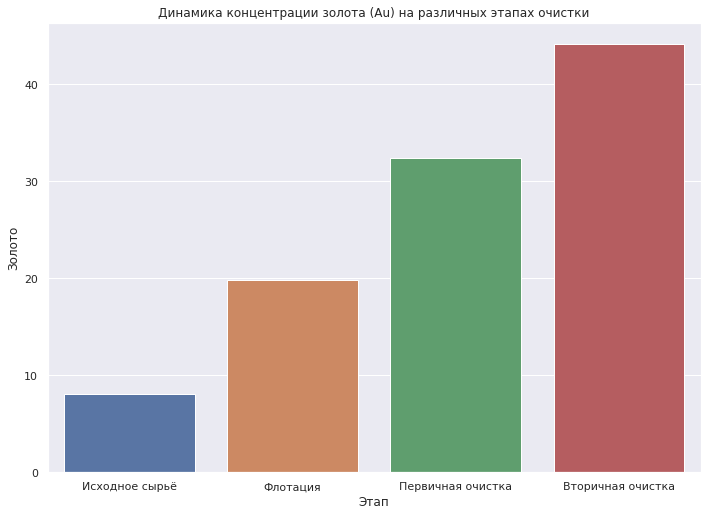

```python
sns.set(rc={'figure.figsize':(11.7,8.27)})
ax = sns.barplot(data=metal_concentration, x="Этап", y="Золото")
ax.set_title('Динамика концентрации золота (Au) на различных этапах очистки');
```

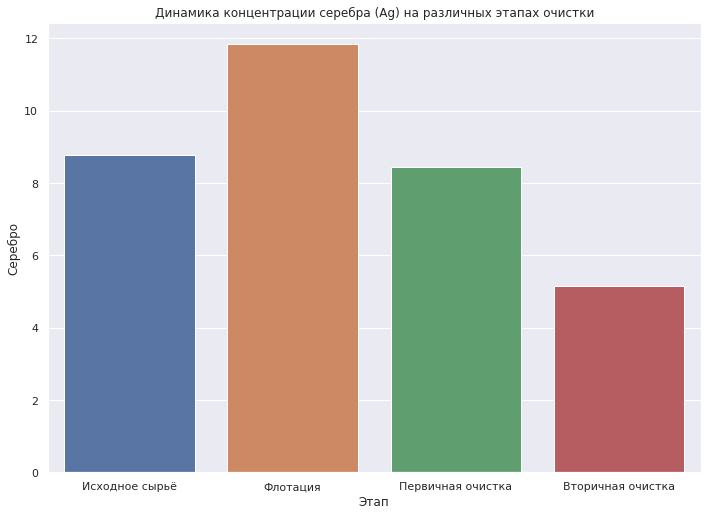

```python
sns.set(rc={'figure.figsize':(11.7,8.27)})
ax = sns.barplot(data=metal_concentration, x="Этап", y="Серебро")
ax.set_title('Динамика концентрации серебра (Ag) на различных этапах очистки');
```

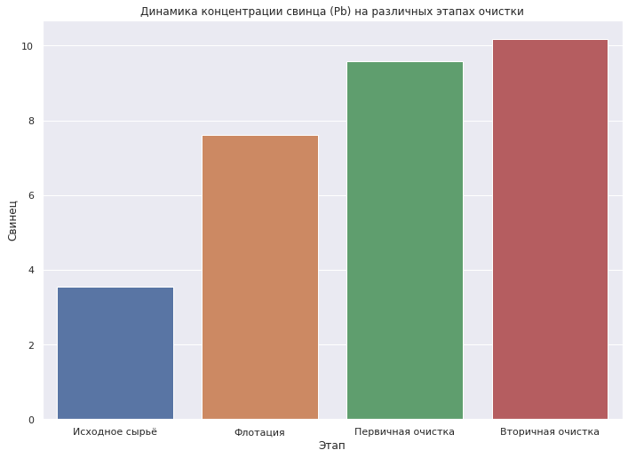

```python
sns.set(rc={'figure.figsize':(11.7,8.27)})
ax = sns.barplot(data=metal_concentration, x="Этап", y="Свинец")
ax.set_title('Динамика концентрации свинца (Pb) на различных этапах очистки');
```

**Выводы**

Из таблицы и графиков видно, что концентрация золота и свинца с каждым этапом увеличивается (очень странно, возможно ошибся в расчётах). Концентрация серебра увеличвается после флотациии и затем уменьшается после этапов первичной и вторичной очистки.

#### Распределение размеров гранул сырья в обучающей и тестовой выборках

Сравним распределения размеров гранул сырья в обучающей и тестовой выборках. Если распределения сильно отличаются друг от друга, оценка модели будет неправильной.

```python
train_feed_size = train_data[['rougher.input.feed_size', 'primary_cleaner.input.feed_size']]
train_feed_size['sample_type'] = 'Обучающая'
test_feed_size = train_data[['rougher.input.feed_size', 'primary_cleaner.input.feed_size']]
test_feed_size['sample_type'] = 'Тестовая'

train_test_feed_size = pd.concat([train_feed_size, test_feed_size])
```

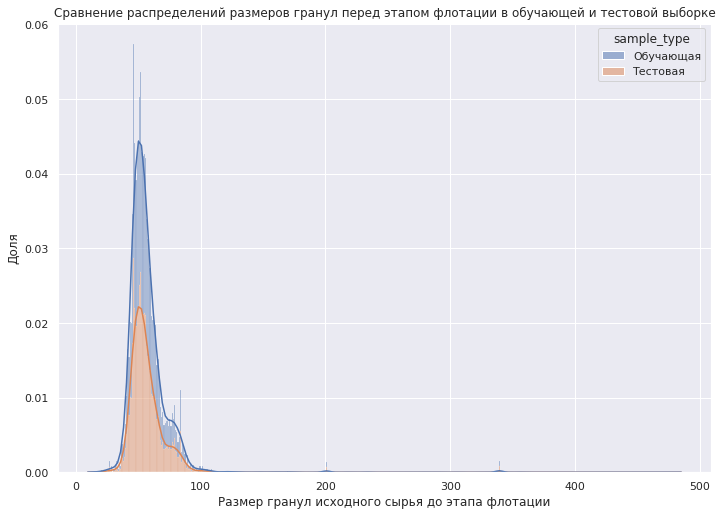

```python
ax = sns.histplot(data=train_test_feed_size,
             x='rougher.input.feed_size',
             hue="sample_type",
             multiple="stack",
             kde=True,
             stat='density')
ax.set_xlabel('Размер гранул исходного сырья до этапа флотации')
ax.set_ylabel('Доля')
ax.set_title('Сравнение распределений размеров гранул перед этапом флотации в обучающей и тестовой выборке');
```

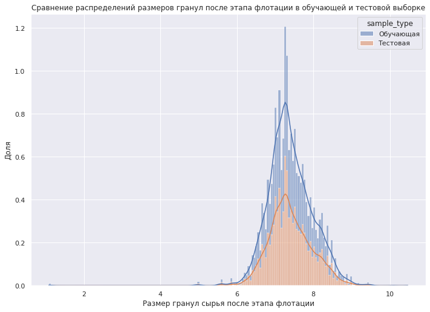

```python
ax = sns.histplot(data=train_test_feed_size,
             x='primary_cleaner.input.feed_size',
             hue="sample_type",
             multiple="stack",
             kde=True,
             stat = 'density')
ax.set_xlabel('Размер гранул сырья после этапа флотации')
ax.set_ylabel('Доля')
ax.set_title('Сравнение распределений размеров гранул после этапа флотации в обучающей и тестовой выборке');
```

**Выводы**

#### Суммарная концентрация всех веществ на разных стадиях

Исследуем суммарную концентрацию всех веществ на разных стадиях: в сырье, в черновом и финальном концентратах.

```python
# До флотации
rougher_input_feed_total = pd.DataFrame()
rougher_input_feed_total['total_concentration'] = train_data['rougher.input.feed_au'] \
+ train_data['rougher.input.feed_ag'] + train_data['rougher.input.feed_pb'] + \
train_data['rougher.input.feed_sol']
rougher_input_feed_total['phase'] = 'Перед флотацией'

# Перед первичной очисткой
rougher_output_concentrate_total = pd.DataFrame()
rougher_output_concentrate_total['total_concentration'] = train_data['rougher.output.concentrate_au'] \
+ train_data['rougher.output.concentrate_ag'] + train_data['rougher.output.concentrate_pb'] + \
train_data['rougher.output.concentrate_sol']
rougher_output_concentrate_total['phase'] = 'Перед первым этапом очистки'

# Перед вторичной очисткой
primary_cleaner_output_concentrate_total = pd.DataFrame()
primary_cleaner_output_concentrate_total['total_concentration'] = train_data['primary_cleaner.output.concentrate_au'] \
+ train_data['primary_cleaner.output.concentrate_ag'] + train_data['primary_cleaner.output.concentrate_pb'] + \
train_data['primary_cleaner.output.concentrate_sol']
primary_cleaner_output_concentrate_total['phase'] = 'Перед вторым этапом очистки'

# На финальной стадии
final_output_concentrate_total = pd.DataFrame()
final_output_concentrate_total['total_concentration'] = train_data['final.output.concentrate_au'] \
+ train_data['final.output.concentrate_ag'] + train_data['final.output.concentrate_pb'] + \
train_data['final.output.concentrate_sol']
final_output_concentrate_total['phase'] = 'На заключительном этапе'

phases_total = pd.concat([rougher_input_feed_total,
                          rougher_output_concentrate_total,
                          primary_cleaner_output_concentrate_total,
                          final_output_concentrate_total
                         ])
```

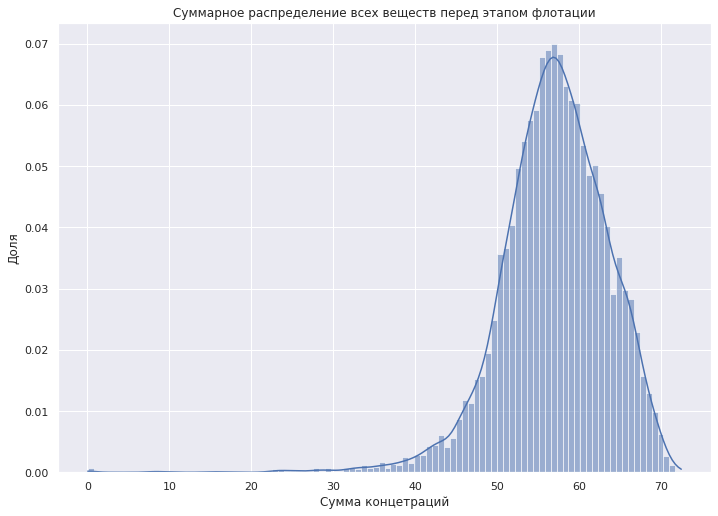

```python
ax = sns.histplot(data=rougher_input_feed_total,
             x='total_concentration',
             multiple="stack",
             kde=True,
             stat = 'density')
ax.set_xlabel('Сумма концетраций')
ax.set_ylabel('Доля')
ax.set_title('Суммарное распределение всех веществ перед этапом флотации');
```

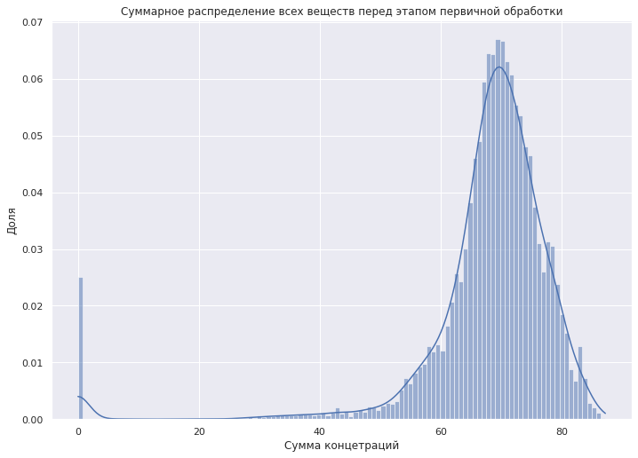

```python
ax = sns.histplot(data=rougher_output_concentrate_total,
             x='total_concentration',
             multiple="stack",
             kde=True,
             stat = 'density')
ax.set_xlabel('Сумма концетраций')
ax.set_ylabel('Доля')
ax.set_title('Суммарное распределение всех веществ перед этапом первичной обработки');
```

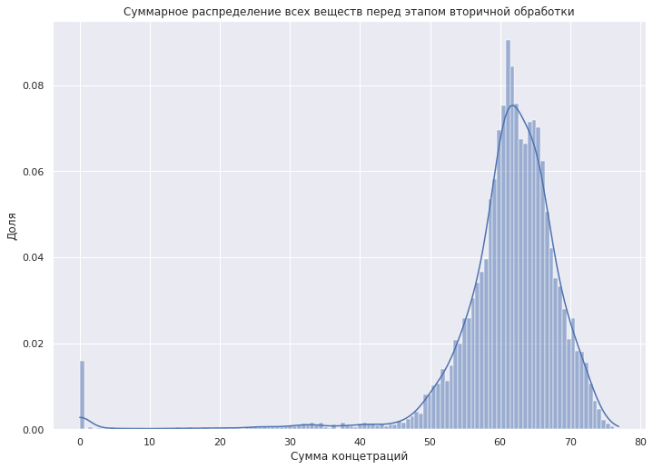

```python
ax = sns.histplot(data=primary_cleaner_output_concentrate_total,
             x='total_concentration',
             multiple="stack",
             kde=True,
             stat = 'density')
ax.set_xlabel('Сумма концетраций')
ax.set_ylabel('Доля')
ax.set_title('Суммарное распределение всех веществ перед этапом вторичной обработки');
```

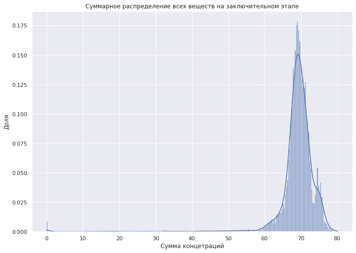

```python
ax = sns.histplot(data=final_output_concentrate_total,
             x='total_concentration',
             multiple="stack",
             kde=True,
             stat = 'density')
ax.set_xlabel('Сумма концетраций')
ax.set_ylabel('Доля')
ax.set_title('Суммарное распределение всех веществ на заключительном этапе');
```

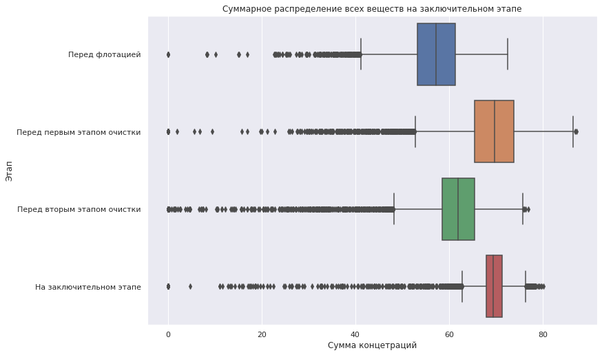

```python
ax = sns.boxplot(data=phases_total, x="total_concentration", y="phase")
ax.set_xlabel('Сумма концетраций')
ax.set_ylabel('Этап')
ax.set_title('Суммарное распределение всех веществ на заключительном этапе');
```

**Выводы**

Суммарная концентрация веществ увеличивается после этапа флотации, уменьшается после первичной очистки и снова увеличивается после вторичной очистки. При этом есть аномалии - значение концентрации, равные нулю (выбросы значений в левой части гистограммы).

## Модель

#### Вычисление итоговой sMAPE

Напишем функцию для вычисления итоговой sMAPE:

```python
def sMAPE(target, predictions, **kwargs):
    target_r = np.array(target['rougher.output.recovery'])
    predictions_r = np.array(predictions[:, 0])
    smape_numerator_r = 0
    smape_numerator_r = (abs(target_r - predictions_r) / ((abs(target_r) + abs(predictions_r) + 1e-10) / 2 )).sum()
    smape_r = smape_numerator_r / len(target_r)

    target_f = np.array(target['final.output.recovery'])
    predictions_f = np.array(predictions[:, 1])
    smape_numerator_f = 0
    smape_numerator_f = (abs(target_f - predictions_f) / ((abs(target_f) + abs(predictions_f) + 1e-10) / 2)).sum()
    smape_f = smape_numerator_f / len(target_f)
    return (0.25 * smape_r + 0.75 * smape_f) * 100
```

#### Выбор лучшей модели

Обучаем разные модели, для каждой подбираем оптимальные гиперпараметры, оцениваем их качество кросс-валидацией.

Напишем свою функцию потерь, которая будет использоваться при оценке качества модели:

```python
my_scorer = make_scorer(sMAPE, greater_is_better=False)
```

Перед применением cross_val_score нужно перемешать данные, если датасет как-то неслучайно упорядочен, что мы как раз имеем в проекте:

```python
features_train, target_train = shuffle(features_train, target_train, random_state=12345)
```

Решающее дерево:

```python
%%time
max_depth = range(1, 11)
hyperparameters_dt = dict(max_depth=max_depth)

model_dt = DecisionTreeRegressor(random_state=12345)
gridsearch_dt = GridSearchCV(model_dt, hyperparameters_dt, scoring=my_scorer)
best_model_dt = gridsearch_dt.fit(features_train, target_train)
print(best_model_dt.best_estimator_)
print("Значение метрики лучшей модели решающего дерева", best_model_dt.best_score_)
```

```
DecisionTreeRegressor(max_depth=10, random_state=12345)
Значение метрики лучшей модели решающего дерева -7.737931328373759
CPU times: user 2.93 s, sys: 0 ns, total: 2.93 s
Wall time: 2.93 s
```

Случайный лес:

```python
%%time
n_estimators = range(10, 51, 10)
max_depth = range(1, 11)
hyperparameters_rf = dict(n_estimators=n_estimators, max_depth=max_depth)

model_rf = RandomForestRegressor(random_state=12345)
gridsearch_rf = GridSearchCV(model_rf, hyperparameters_rf, scoring=my_scorer)
best_model_rf = gridsearch_rf.fit(features_train, target_train)
print(best_model_rf.best_estimator_)
print("Значение метрики лучшей модели случайного леса", best_model_rf.best_score_)
```

```
RandomForestRegressor(max_depth=10, n_estimators=50, random_state=12345)
Значение метрики лучшей модели случайного леса -7.36937648174834
CPU times: user 4min 13s, sys: 406 ms, total: 4min 14s
Wall time: 4min 14s
```

Линейная регрессия (у обычной модели линейной регрессии гиперпараметров нет, поэтому кросс-валидация здесь не нужна, но будем использовать в качестве метрики, так она использовалась для других моделей):

```python
model_lr = LinearRegression() # инициализация модели линейной регрессии
scores = cross_val_score(model_lr, features_train, target_train, cv=5, scoring=my_scorer)
final_score = scores.mean()
print('Значение метрики для модели линейной регрессии:', final_score)
```

```
Значение метрики для модели линейной регрессии: -8.415021411002005
```

#### Тестирование модели

```python
best_model = RandomForestRegressor(random_state=12345,
                                           n_estimators=50,
                                           max_depth=9)
best_model.fit(features_train, target_train)
predictions_test = best_model.predict(features_test)

score = sMAPE(target_test, predictions_test)

print('sMAPE модели', score)
```

```
sMAPE модели 8.928809011436075
```

Сравниваем значение с константной моделью:

```python
dummy_regr = DummyRegressor(strategy="mean")
dummy_regr.fit(features_train, target_train)
predictions_test = dummy_regr.predict(features_test)

score = sMAPE(target_test, predictions_test)

print('sMAPE константной модели', score)
```

```
sMAPE константной модели 9.736782265631685
```

**Выводы**

Значение sMAPE константной модели 9.74, итоговой - 8.93. Модель проходит проверку на адекватность.